# Tutorial 9: Random slope models

Forschungspraktikum I und II: Vergleichende Sozialforschung mit Mehrebenenmodellen in R

Dr. Christian Czymara (Sociology with Focus on Quantitative Methods for Social Research, Goethe University Frankfurt)

In this exercise, we will analyze the relationship between respondents’ view on the welfare state (measured by the item *“Social benefits/services lead to a more equal society”*, `sbeqsoc`) and their political orientation (measured by left-right-scale, `lrscale`), using the ESS 2016/17.

## 1. Importing data

Import ESS8_edit_cent.dta and assign it to object `ESS8`. In this data, continuous individual level predictors are centered at their grand mean (variables ending with *_cent). Recode `sbeqsoc` so that higher values imply a more positive attitude.

```r
setwd("C:/Users/czymara.local/Nextcloud/teaching/FoP HLM/_R/09_random_slope_models")

library("haven")

ESS8 <- read_dta("ESS8_edit_cent.dta")

# recode outcome
ESS8$sbeqsoc_org <- ESS8$sbeqsoc
ESS8$sbeqsoc <- 6-ESS8$sbeqsoc

# compare
table(ESS8$sbeqsoc, ESS8$sbeqsoc_org)
```

```
##
##         1     2     3     4     5
##   1     0     0     0     0  1016
##   2     0     0     0  5469     0
##   3     0     0  6364     0     0
##   4     0 12496     0     0     0
##   5  1758     0     0     0     0
```

## 2. Random intercept model

As a first step, we want to know whether welfare state attitudes correlate with political orientation. Estimate a hierarchical linear model that regresses `sbeqsoc` on `lrscale_cent` (with a random intercept for `cntry`):

$$sbeqsoc_{ij}=\beta_0+\beta_1lrscale\_cent_{ij}+u_{0j}+e_{ij}$$

```r
library(lme4)

RIM <- lmer(sbeqsoc ~ lrscale_cent + (1 | cntry), data = ESS8)

summary(RIM, correlation = F)
```

```
## Linear mixed model fit by REML ['lmerMod']
## Formula: sbeqsoc ~ lrscale_cent + (1 | cntry)
##    Data: ESS8
##
## REML criterion at convergence: 74326.7
##
## Scaled residuals:
##     Min      1Q  Median      3Q     Max
## -2.8923 -0.6717  0.3589  0.6896  2.4161
##
## Random effects:
##  Groups   Name        Variance Std.Dev.
##  cntry    (Intercept) 0.07405  0.2721
##  Residual             0.90552  0.9516
## Number of obs: 27103, groups:  cntry, 19
##
## Fixed effects:
##               Estimate Std. Error t value
## (Intercept)   3.305078   0.062713  52.702
## lrscale_cent -0.018753   0.002691  -6.969
```

## 3. Random slope model

### a) Varying effect of political orientation

We want to know whether the relationship between welfare state attitudes and political orientation differs across countries. Estimate a model including a random slope for the (centered) political orientation variable:

$$sbeqsoc_{ij}=\beta_0+\beta_1lrscale\_cent_{ij}+u_{0j}+u_{1j}lrscale\_cent_{ij}+e_{ij}$$

Interpret the coefficient of the fixed ($\beta_1$) and of the random effect ($\tau_{11}=var(u_{1j})$) of political orientation.

```r
RSlope <- lmer(sbeqsoc ~ lrscale_cent + (1 + lrscale_cent | cntry), data = ESS8) # unstructured covariance matrix

summary(RSlope, correlation = F)
```

```
## Linear mixed model fit by REML ['lmerMod']
## Formula: sbeqsoc ~ lrscale_cent + (1 + lrscale_cent | cntry)
##    Data: ESS8
##
## REML criterion at convergence: 74220.3
##
## Scaled residuals:
##     Min      1Q  Median      3Q     Max
## -3.0840 -0.6916  0.3447  0.6898  2.4296
##
## Random effects:
##  Groups   Name         Variance Std.Dev. Corr
##  cntry    (Intercept)  0.077411 0.27823
##           lrscale_cent 0.001048 0.03237  -0.42
##  Residual              0.900754 0.94908
## Number of obs: 27103, groups:  cntry, 19
##
## Fixed effects:
##               Estimate Std. Error t value
## (Intercept)   3.300514   0.064115  51.478
## lrscale_cent -0.017267   0.007909  -2.183
## optimizer (nloptwrap) convergence code: 0 (OK)
## Model failed to converge with max|grad| = 0.00453202 (tol = 0.002, component 1)
```

```r
# Fixed effect: For an "average" country, one more point on the LR scale is associated with a 0.017 decrease in welfare state attitude --> slope of average regression line
# Random effect: How much does this effect vary across countries? 0.001 --> variance of the slope

# 95 percent interval of the random slope (note: use standard deviation):
RSlope@beta[2] - 1.96*as.data.frame(VarCorr(RSlope))$sdcor[2] # lower bound
```

```
## [1] -0.08070832
```

```r
RSlope@beta[2] + 1.96*as.data.frame(VarCorr(RSlope))$sdcor[2] # upper bound
```

```
## [1] 0.04617422
```

```r
# for 95 percent of countries, the expected effect of LR scale lies between -0.08 and 0.046
```

### b) Likelihood-Ratio test

Does the effect of political orientation vary across countries? Run a Likelihood-Ratio test (LR test) to compare the model with random slopes to the model without random slopes (with $h_0:~\tau_{01}=\tau_{11}=0$).

```r
library(lmtest)
lrtest(RIM, RSlope)
```

```
## Likelihood ratio test
##
## Model 1: sbeqsoc ~ lrscale_cent + (1 | cntry)
## Model 2: sbeqsoc ~ lrscale_cent + (1 + lrscale_cent | cntry)
##   #Df LogLik Df  Chisq Pr(>Chisq)
## 1   4 -37163
## 2   6 -37110  2 106.48  < 2.2e-16 ***
## ---
## Signif. codes:  0 '***' 0.001 '**' 0.01 '*' 0.05 '.' 0.1 ' ' 1
```

### c) Random effects

Use `ranef()` to access the random intercepts and slopes for each country (add `condVar = TRUE` to take covariance matrix into account). Can you name a country where people were rather *negative* about the welfare state but where the expected effect of political orientation is *stronger* than average? What about a country where welfare views are rather *positive* but the expected effect of political orientation is *weaker*?

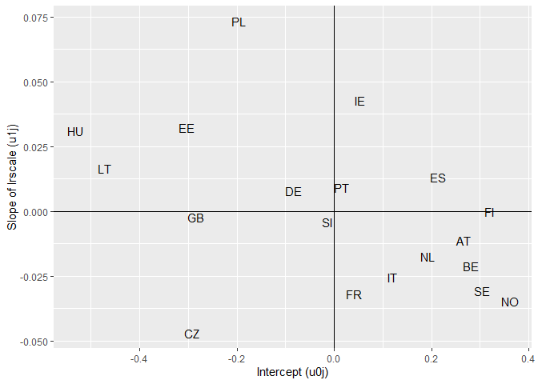

```r
randomEffects <- ranef(RSlope, condVar = TRUE)

# inspect random effects for each country
randomEffects_df <- as.data.frame(ranef(RSlope, condVar = TRUE)$cntry) # as data frame
randomEffects_df$cntry <- rownames(randomEffects_df) # add country names variable

# plot
library(tidyverse)

randomEffects_df %>%
  ggplot(aes(x = `(Intercept)`,
             y = lrscale_cent,
             label = cntry)) +
  stat_summary(fun = mean,
               geom = "text") +
  xlab("Intercept (u0j)") +
  ylab("Slope of lrscale (u1j)") +
  geom_vline(xintercept = 0) +
  geom_hline(yintercept = 0)
```

### d) Covariance structure

Based on the results above, is $\beta_1$ positive or negative? Is $\tau_{01}$ (the covariance between the random intercept and the random slope, $cov(u_{0j}, u_{1j})$) positive or negative? Which pattern of slopes does this imply?

```r
# (co-)variance structure
VarCorr(RSlope)
```

```
##  Groups   Name         Std.Dev. Corr
##  cntry    (Intercept)  0.278229
##           lrscale_cent 0.032368 -0.420
##  Residual              0.949081
```

```r
print(VarCorr(RSlope),comp="Variance")
```

```
##  Groups   Name         Variance  Corr
##  cntry    (Intercept)  0.0774112
##           lrscale_cent 0.0010477 -0.420
##  Residual              0.9007543
```

```r
# beta positive?
RSlope@beta[2] > 0 # on average, lines will fall
```

```
## [1] FALSE
```

```r
# tau positive?
as.data.frame(VarCorr(RSlope))$sdcor[3] > 0 # fanning in pattern
```

```
## [1] FALSE
```

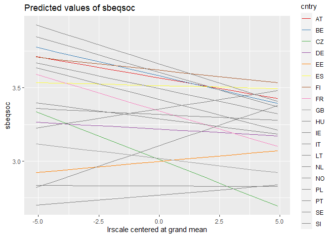

```r
# plot
library(sjPlot)

plot_model(RSlope,
           type="pred",
           terms=c("lrscale_cent", "cntry"),
           pred.type = "re",
           ci.lvl = NA
           )
```

### e) Control variables

Add the following control variables on the individual-level: `hinctnta_cent`, `res_educ`, `laborstat`, and the country-level control `gdppc`:

$$sbeqsoc_{ij}=\beta_0+\beta_1lrscale\_cent_{ij}+\beta_2hinctnta\_cent_{ij}+\beta_3res\_educ\_2_{ij}+\beta_4res\_educ\_3_{ij}+\beta_5res\_educ\_4_{ij}+\beta_6laborstat\_2_{ij}+\beta_7laborstat\_3_{ij}+\gamma_1gdppc_j+u_{0j}+u_{1j}lrscale\_cent_{ij}+e_{ij}$$

Are the results regarding the association between welfare state attitudes and political orientation stable to the inclusion of the control variables?

```r
RSlope_cont <- lmer(sbeqsoc ~ lrscale_cent + hinctnta_cent + factor(res_educ) + factor(laborstat) + gdppc + (1 + lrscale_cent | cntry), data = ESS8)

tab_model(RIM, RSlope, RSlope_cont)
```

|  | sbeqsoc |  |  | sbeqsoc |  |  | sbeqsoc |  |  |
| --- | --- | --- | --- | --- | --- | --- | --- | --- | --- |
| Predictors | Estimates | CI | p | Estimates | CI | p | Estimates | CI | p |
| (Intercept) | 3.31 | 3.18 – 3.43 | **<0.001** | 3.30 | 3.17 – 3.43 | **<0.001** | 2.79 | 2.43 – 3.15 | **<0.001** |
| lrscale centered at grand mean | -0.02 | -0.02 – -0.01 | **<0.001** | -0.02 | -0.03 – -0.00 | **0.029** | -0.02 | -0.03 – -0.00 | **0.034** |
| hinctnta centered at grand mean |  |  |  |  |  |  | 0.00 | -0.00 – 0.01 | 0.135 |
| factor(res_educ)2 |  |  |  |  |  |  | -0.14 | -0.18 – -0.10 | **<0.001** |
| factor(res_educ)3 |  |  |  |  |  |  | -0.10 | -0.13 – -0.07 | **<0.001** |
| factor(res_educ)4 |  |  |  |  |  |  | -0.06 | -0.09 – -0.02 | **0.003** |
| factor(laborstat)2 |  |  |  |  |  |  | 0.10 | 0.06 – 0.14 | **<0.001** |
| factor(laborstat)3 |  |  |  |  |  |  | 0.04 | 0.02 – 0.07 | **0.001** |
| GDP per head(PPP,1000$) |  |  |  |  |  |  | 0.02 | 0.01 – 0.03 | **0.002** |
| Random Effects |  |  |  |  |  |  |  |  |  |
| σ<sup>2</sup> | 0.91 |  |  | 0.90 |  |  | 0.90 |  |  |
| τ<sub>00</sub> | 0.07 <sub>cntry</sub> |  |  | 0.08 <sub>cntry</sub> |  |  | 0.05 <sub>cntry</sub> |  |  |
| τ<sub>11</sub> |  |  |  | 0.00 <sub>cntry.lrscale_cent</sub> |  |  | 0.00 <sub>cntry.lrscale_cent</sub> |  |  |
| ρ<sub>01</sub> |  |  |  | -0.42 <sub>cntry</sub> |  |  | -0.36 <sub>cntry</sub> |  |  |
| ICC | 0.08 |  |  | 0.08 |  |  | 0.06 |  |  |
| N | 19 <sub>cntry</sub> |  |  | 19 <sub>cntry</sub> |  |  | 19 <sub>cntry</sub> |  |  |
| Observations | 27103 |  |  | 27103 |  |  | 27103 |  |  |
| Marginal R<sup>2</sup> / Conditional R<sup>2</sup> | 0.002 / 0.077 |  |  | 0.001 / 0.085 |  |  | 0.028 / 0.082 |  |  |